# Correlation Homework

Checking assumptions before choosing a correlation

Author

## The Idea

A correlation statistic is only as good as the assumptions behind it. Pearson’s product-moment correlation assumes each variable is (at least roughly) normally distributed; Spearman’s rank correlation does not. So a reproducible analysis does not just run `cor.test()`. It works down a short decision path and lets the data make each choice:[^1]

1. **Test normality.** If both variables are normal, use Pearson’s correlation.
2. **If not, try to transform.** If a transformation makes both variables normal, use Pearson’s correlation on the transformed values.
3. **If no transformation works, use ranks.** Spearman’s $\rho$ makes no normality assumption.
4. **If the *P*-value is only an approximation, permute.** Tied ranks keep `R` from computing an exact *P*-value for Spearman’s test; a permutation test estimates it directly from the data.

The write-up then reports every step it took, with every number read from a variable in memory using an inline `` `r ` `` expression, never typed by hand.

This assignment has you practice that habit on the beer styles data from the module. Read the worked example, then reproduce its structure for beer color and final gravity.

## A Worked Example

### Methods

> **Data.** We used the Beer Judge Certification Program style guidelines for 100 recognized beer styles, distributed through the course data repository. For each style the guidelines give a minimum and maximum value for alcohol content (ABV, % by volume), bitterness (IBU), color (SRM), and original and final gravity (OG, FG). For this example we pulled the maximum ABV and the maximum IBU for every style into a pair of vectors.

```r
library( tidyverse )
beer_url <- "https://dyerlabteaching.github.io/CourseData/Miscellaneous/Beer_Styles.csv"
beer <- read_csv( beer_url )
abv <- beer$ABV_Max
ibu <- beer$IBU_Max
```

> **Normality.** We first evaluated whether each variable could be considered normally distributed, visually with a normal quantile plot and formally with a Shapiro-Wilk test.

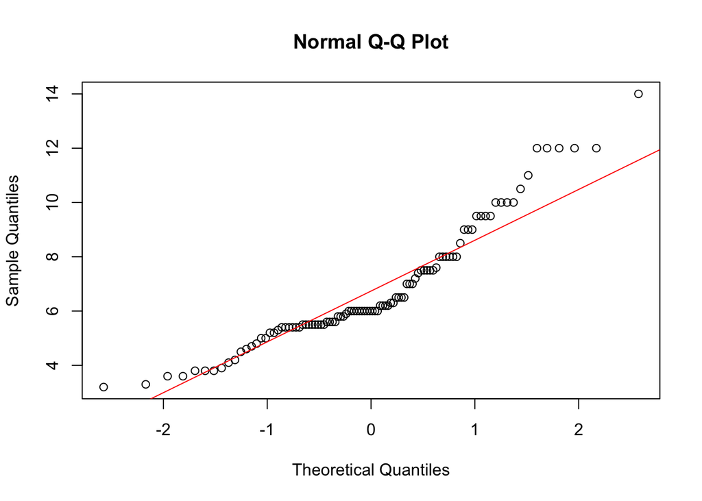

```r
qqnorm( abv )
qqline( abv, col = "red" )
```

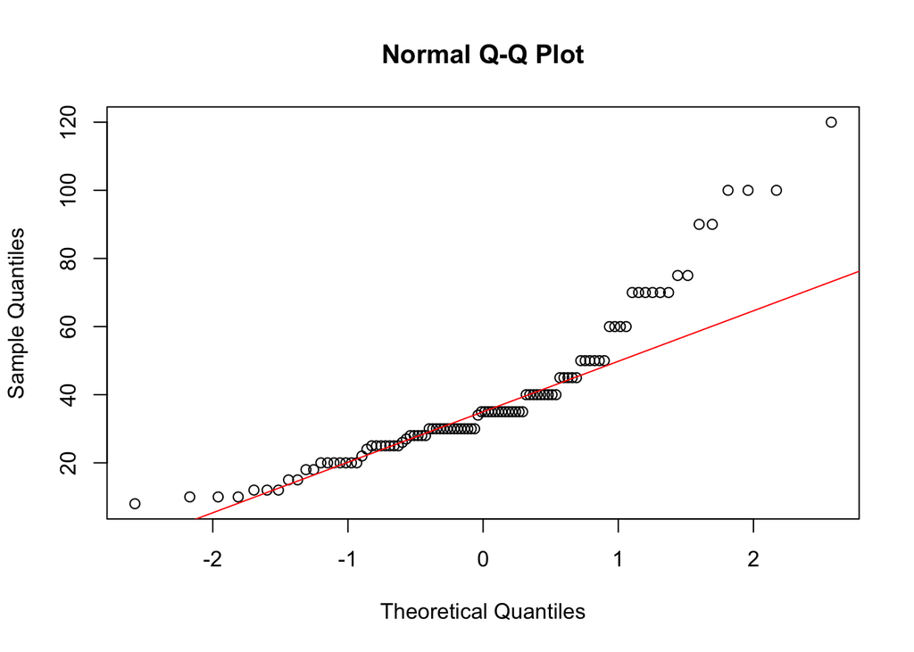

```r
qqnorm( ibu )
qqline( ibu, col = "red" )
```

```r
norm_abv <- shapiro.test( abv )
norm_ibu <- shapiro.test( ibu )
norm_abv
```

```
    Shapiro-Wilk normality test

data:  abv
W = 0.91327, p-value = 6.293e-06
```

```r
norm_ibu
```

```
    Shapiro-Wilk normality test

data:  ibu
W = 0.87211, p-value = 8.539e-08
```

> **Transformation.** Because neither variable was normally distributed, we log-transformed both and tested them again.

```r
log_abv <- log( abv )
log_ibu <- log( ibu )
norm_log_abv <- shapiro.test( log_abv )
norm_log_ibu <- shapiro.test( log_ibu )
norm_log_abv
```

```
    Shapiro-Wilk normality test

data:  log_abv
W = 0.97105, p-value = 0.02663
```

```r
norm_log_ibu
```

```
    Shapiro-Wilk normality test

data:  log_ibu
W = 0.97751, p-value = 0.08491
```

The log transformation was enough for IBU but not for ABV. Pearson’s correlation needs *both* variables to be normal, so a transformation that fixes only one of them does not get us there.

> **Correlation.** Because no transformation made both variables normal, we estimated their association on the original scale with Spearman’s rank correlation, $\rho$, which does not assume normality, using `cor.test()` with `method = "spearman"`.

```r
fit <- cor.test( abv, ibu, method = "spearman" )
```

```
Warning in cor.test.default(abv, ibu, method = "spearman"): cannot compute
exact p-value with ties
```

```r
fit
```

```
    Spearman's rank correlation rho

data:  abv and ibu
S = 96565, p-value = 1.322e-05
alternative hypothesis: true rho is not equal to 0
sample estimates:
      rho
0.4205513
```

Spearman’s test works on ranks, and several styles share the same maximum ABV or IBU. Those tied ranks are why `R` warns that it “cannot compute exact p-value with ties” and uses an approximation instead. The warning is expected and is not an error, but it does mean the *P*-value above is an estimate, so we check it with a permutation test.

> **Permutation.** To get a *P*-value that does not depend on that approximation, we shuffled the IBU values 999 times, recomputed Spearman’s $\rho$ for each shuffle, and counted how often a shuffled correlation was at least as large (in absolute value) as the observed one. The observed value counts as one of the 1,000.

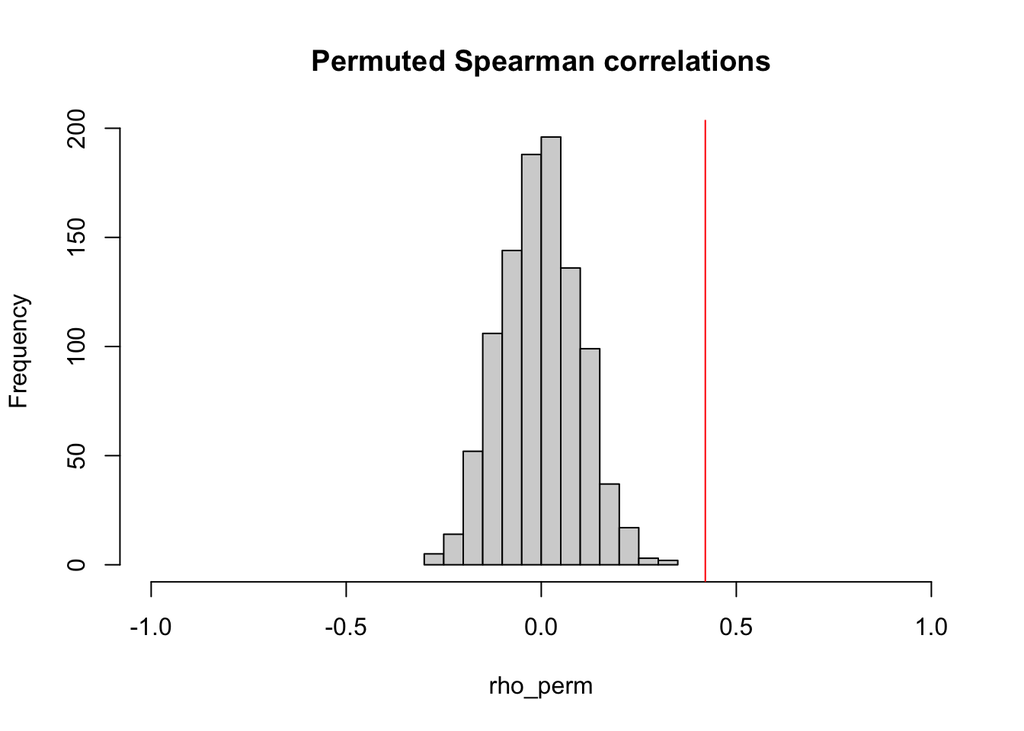

```r
set.seed( 543 )
rho_perm <- numeric( 999 )
for( i in 1:999 ) {
  rho_perm[i] <- cor( abv, sample( ibu ), method = "spearman" )
}
hist( rho_perm, xlim = c( -1, 1 ), main = "Permuted Spearman correlations" )
abline( v = fit$estimate, col = "red" )
```

```r
P_perm <- ( sum( abs( rho_perm ) >= abs( fit$estimate ) ) + 1 ) / 1000
P_perm
```

```
[1] 0.001
```

The red line is the observed correlation, far outside every shuffled value, so the permutation *P*-value is as small as 999 shuffles can measure: 1/1000.

### Preparing the reporting values

Before writing a word of the Results, pull the numbers you are going to report out of the test objects and format them. Doing that work in one small chunk, and giving each value a short name, keeps `format()` calls out of the prose. Notice that `norm_abv`, `norm_log_abv`, and `fit` are all the same kind of object, so they share the same parts: `$statistic`, `$p.value`, and (for the correlation) `$estimate`.

```r
W_abv <- format( norm_abv$statistic, digits = 3 )
P_abv <- format( norm_abv$p.value,   digits = 3 )
W_ibu <- format( norm_ibu$statistic, digits = 3 )
P_ibu <- format( norm_ibu$p.value,   digits = 3 )

P_log_abv <- format( norm_log_abv$p.value, digits = 3 )
P_log_ibu <- format( norm_log_ibu$p.value, digits = 3 )

rho <- format( fit$estimate, digits = 3 )
P   <- format( fit$p.value,  digits = 3 )
N   <- length( abv )
```

### Results

> Neither maximum ABV (Shapiro-Wilk *W* = 0.913, *P* = 6.29e-06) nor maximum IBU (*W* = 0.872, *P* = 8.54e-08) was normally distributed across the 100 beer styles. A log transformation normalized IBU (*P* = 0.0849) but not ABV (*P* = 0.0266). Using a rank-based test on the original values, maximum ABV and maximum IBU were moderately and positively correlated (Spearman’s $\rho$ = 0.421, approximate *P* = 1.32e-05), and a permutation test confirmed it (*P* = 0.001, 999 permutations): stronger styles tend to be allowed more bitterness.

Here is the raw text that produced it:

```
Neither maximum ABV (Shapiro-Wilk *W* = `r W_abv`, *P* = `r P_abv`) nor maximum IBU (*W* = `r W_ibu`, *P* = `r P_ibu`) was normally distributed across the `r N` beer styles. A log transformation normalized IBU (*P* = `r P_log_ibu`) but not ABV (*P* = `r P_log_abv`). Using a rank-based test on the original values, maximum ABV and maximum IBU were moderately and positively correlated (Spearman's $\rho$ = `r rho`, approximate *P* = `r P`), and a permutation test confirmed it (*P* = `r P_perm`, 999 permutations): stronger styles tend to be allowed more bitterness.
```

## Your Assignment

Following the worked example, produce a standalone **Methods** and **Results** write-up for the correlation between **maximum color (`SRM_Max`) and maximum final gravity (`FG_Max`)** across all 100 beer styles. Work down the same decision path, and let your results make each choice. Do not just copy the worked example’s.

Your document should have:

1. **Methods**, each step a short paragraph followed by its chunk:
   - *Data*: load the beer data and pull out the two vectors;
   - *Normality*: a `qqnorm()` plot and a `shapiro.test()` for each variable;
   - *Transformation* (if needed): transform the variables that are not normal and test them again. Try at least one transformation from the narrative and say whether it worked;
   - *Correlation*: say which method you chose and why, then run `cor.test()`;
   - *Permutation* (if needed): if `R` could only approximate your *P*-value, estimate it with 999 permutations.
2. **A reporting-values chunk**: `format()` the numbers your Results report and give each a short name.
3. **Results**: one paragraph reporting every step you took, with each number as a bare inline value (`0.421`) and no `format()` in the prose.

Then answer briefly, a sentence or two each:

- Spearman’s $\rho$ is computed from the *ranks* of the data rather than the raw values. Why does that free it from the normality assumption, and what information about the data do you give up in exchange?
- Darker beer styles tend to have higher final gravity. Does your result show that making a beer darker makes it sweeter and fuller-bodied? Explain what a correlation can and cannot tell you here.

## What You Turn In

**One file: the rendered, self-contained `.html`.** Not the `.qmd`, and not a copy of this page. Make a *new* Quarto document that contains only your own work: your Methods and Results sections with their chunks, the reporting-values chunk, and your brief answers to the two questions.

The worked example above is a model to imitate, not text to paste into your document.

### Making the document

1. In RStudio: **File ▸ New File ▸ Quarto Document…**
2. In the dialog, enter a title and your name, leave the engine set to **Knitr**, and click **Create**.
3. Delete everything RStudio puts below the header (the “Quarto” boilerplate and its example chunk).
4. Replace the header it generated with the one below.
5. Save the file into your course project folder as `Correlation-Homework.qmd`.
6. Write your content, then click **Render** to produce the `.html`. That HTML file is what you submit.

### The full YAML header

```yaml
---
title: "Correlation Homework"
author: "Your Name"
date: today
abstract: |
  A sentence or two saying what the document does: the data, the question, and what you found.
format:
  html:
    self-contained: true
    code-tools: true
---
```

- **`title` / `author` / `date` / `abstract`**: complete front matter, including a short summary where a scientific paper would put its abstract. `date: today` fills itself in at render time.
- **`format: html`**: render to a single web page I can open in any browser.
- **`self-contained: true`**: bundle every image, style, and script *into* that one `.html` file. Without it the file depends on a sibling `*_files/` folder that never makes it into the upload, and your figures and formatting arrive broken.
- **`code-tools: true`**: adds the “</> Code” button in the top-right that lets a reader view the full source. **This is not optional.** If I cannot see the code behind a wrong answer, I cannot tell whether you were one typo away or lost the plot entirely. That means I cannot give partial credit, point out where it went sideways, or help you fix it. A rendered page with no visible code is graded only on what rendered.

Use this same header layout for every document you turn in this course.

## How This Is Graded

This assignment is scored with the **Online Homework Rubric** on the Canvas site, the same rubric used for every online homework in this course. It covers online access to the published document, front matter, formatting, and whether the document stands on its own; the remaining points come from the assignment-specific work above.

## Footnotes

[^1]: Normality testing with `qqnorm()` and `shapiro.test()` is covered in the narrative section [Testing for Normality](https://dyerlabteaching.github.io/Correlation/narrative.html#testing-for-normality.), transformations in [Transformations](https://dyerlabteaching.github.io/Correlation/narrative.html#transformations), the two correlation methods in [Pearson](https://dyerlabteaching.github.io/Correlation/narrative.html#parametric-test-pearson-product-moment-correlations) and [Spearman](https://dyerlabteaching.github.io/Correlation/narrative.html#non-parametric-test-spearmans-rho), and permutation in [Permutation Testing for Significance](https://dyerlabteaching.github.io/Correlation/narrative.html#permutation-testing-for-significance).